# ICT 782 - Day 5 Notes

# Plotting and Visualization

An important part of data analysis is visualization. This includes producing appealing visualizations of both cleaned and transformed data as well as the results of our analyses. Today, we will explore various plot types available in Matplotlib and, by extension, for pandas objects.

Before we proceed with plotting, we recall some basic rules for visually presenting data:

1. Make the scale of your graphic clear. For non-negative numerical data, the vertical axis should start at 0. For numerical data on the horizontal axis, use the full range of available data.
2. Say something. Don't produce a plot where no plot is necessary. Conversely, a single plot will eliminate the need for complicated explanations.
3. Use the right plot for the right data. Don't use a bar chart when you really want a histogram. Similarly, don't use a pie chart when a bar chart will more clearer make the point.
4. Use colors and style to make your point clearer, not less clear. Don't label every single data point, and don't use Excel-style 3D plots - they are nearly impossible to read. 3D plots are ok in some cases, just be judicious.

For a complete guide to plotting, check out the book 'Graphic Presentation' by Willard C. Brinton. This book was published in 1939, but most of the plot styles are still in current use, and the principles of good visualization are timeless!

## Matplotlib

Though there are many sophisticated plotting packages for Python, Matplotlib is *the* foundational plotting package. Based on NumPy, Matplotlib works beautifully with pandas objects. There are many modules contained in Matplotlib. For general plotting, we'll import the Pyplot module under the alias `plt`.

The cell magic `%matplotlib inline` tells the Jupyter notebook to allow plotting after the cell in which it is called. This cell magic only needs to be called once per notebook.

```python
%matplotlib inline

import numpy as np
import pandas as pd
import matplotlib.pyplot as plt
```

Before we dig into the details of the package, let's see an example.

### Loading and displaying images with Matplotlib

As mentioned briefly on Day 1, Matplotlib has Matlab-like tools for loading and displaying images. Using the `image` module of Matplotlib, we can call the `imread(<filepath>)` function to load an image into the interpreter. We then use the `imshow()` function from the `pyplot` module to display the image. I often place a semi-colon after the `imshow()` function is called to suppress printing the object type to the console.

Since the `cameraman.jpg` image is grayscale, we'll specify the colormap using the keyworded argument `cmap = 'gray'`.

[figure not shown]

```python
import matplotlib.image as mp

im = mp.imread('cameraman.jpg')
plt.imshow(im, cmap = 'gray');
```

Some common colormaps (the `cmap` argument) are `bone`, `gray`, `hot`, and `summer`.

**Side note:** Another way to display images in Jupyter notebooks is with the `![hover text](image filepath)` syntax.

[figure not shown]

## Matplotlib objects: the structure of plots

There are, of course, shortcuts to plotting with Matplotlib. However, understanding the underlying structure of Matplotlib plots opens a much wider range of customizable plots. In this section, we'll explore the fundamental objects in Matplotlib.

### The `figure` object

The most basic object in Matplotlib is the `figure`. This object contains attributes for the plotting metadata such as the axes, the plot resolution, the size of the plot, and the background color. When we generate a `figure`, we can also specify its `number` attribute so that we can access various `figure` objects by their `number`. All plotting metadata attributes can be passed as keyworded arguments, and are summarized in the following table.

[output not shown]

```python
fig1 = plt.figure(num = 1,
                  figsize = (10, 5),
                  dpi = 250,
                  facecolor = 'm',
                  edgecolor = 'k')
```

Note that we passed in *inches* for the `figsize` attribute, but the `figure` has its size determined by `pixels`. This is because the `dpi` value is literally *dots per inch*. In other words, we specify the pixels per square inch and the `figsize`, and the Python interpreter does the arithmetic for us.

When `fig1` was generated, the console output was `<Figure size 2500x1250 with 0 Axes>`. This tells us that we have an empty `figure` object. We'll now focus on the second important object in Matplotlib: the `axes` object.

### The `axes` object

With a `figure` generated, we can place an `axes` object onto it. Think of this as creating a canvas (generating the `figure`) and then preparing an area of the canvas for your painting (generating the `axes`). We will use the `add_subplot()` method of the `figure` object to add an `axes` to our `figure`.

```python
ax1 = fig1.add_subplot()
```

We didn't specify any arguments for the `add_subplot()` method. However, the default argument is `1,1,1` or, equivalently, `111`. These positional arguments are *not* specified in the official documentation as keyworded arguments, which makes them unnecessarily vague. However, they mean `number_of_rows, number_of_columns, index`. In other words, they specify the number of sub-plots our `figure` will have and the position of our generated `axes` object.

By passing in `1,1,1`, we are telling the `figure` that we want a sub-plot with 1 row, 1 column, and the `axes` object is in index position 1. Index positions are read left-to-right, top-to-bottom.

### *Example:* Plotting with `figure` and `axes` objects

This might be confusing, so let's actually plot some `axes` to see what's going on. We'll create a new `figure` and two `axes` objects. To identify our `axes` positions, we'll use the `set_title()` method.

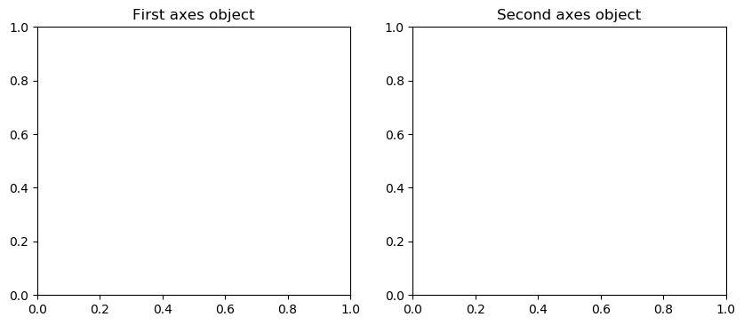

```python
fig = plt.figure(num = 2,
                 figsize = (10, 4),
                 dpi = 100,
                 facecolor = 'w',
                 edgecolor = 'k')

# Here we state that our figure has 1 row, 2 columns.
ax1 = fig.add_subplot(1,2,1)
ax2 = fig.add_subplot(1,2,2)

ax1.set_title('First axes object');
ax2.set_title('Second axes object');
```

The above code to generate the `figure` and `axes` objects is largely illustrative. In practice and in tutorials, we most often see the `figure` and `axes` declared in one line.

**Note:** Generating a `figure` with more than one row or column results in the creation of an *array* of `axes` objects. We can access individual `axes` objects in this array by indexing.

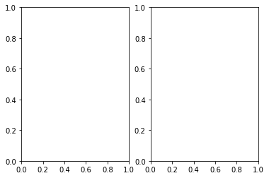

```python
fig, ax = plt.subplots(1,2)
```

```python
ax
```

[output not shown]

```python
ax[0]
```

### `axes` methods

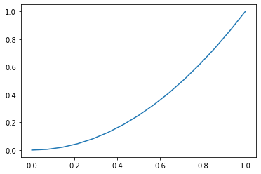

```python
fig, ax = plt.subplots()

x = np.linspace(0,1,15)
y = x**2

ax.plot(x,y);
```

To plot individual data points instead of a smooth curve, we use the `scatter()` method.

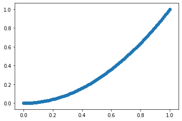

```python
fig, ax = plt.subplots()

x = np.linspace(0,1,100)
y = x**2

ax.scatter(x,y);
```

That's looking a little dense, so we can either reduce the number of points in `x` or change the `marker` to make the points easier to see.

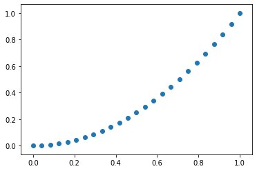

```python
# Reducing the number of points.

fig, ax = plt.subplots()

x = np.linspace(0,1,25)
y = x**2

ax.scatter(x,y);
```

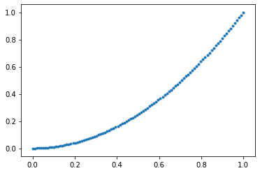

```python
# Changing the marker.

fig, ax = plt.subplots()

x = np.linspace(0,1,100)
y = x**2

ax.scatter(x,y, marker = '.');
```

The full list of markers is listed below (from the official documentation). Some examples are plotted below for clarification.

| Marker | Details |
| --- | --- |
| `'.'` | point |
| `','` | pixel |
| `'o'` | circle |
| `'v'` | triangle_down |
| `'^'` | triangle_up |
| `'<'` | triangle_left |
| `'>'` | triangle_right |
| `'1'` | tri_down |
| `'2'` | tri_up |
| `'3'` | tri_left |
| `'4'` | tri_right |
| `'s'` | square |
| `'p'` | pentagon |
| `'*'` | star |
| `'h'` | hexagon1 |
| `'H'` | hexagon2 |
| `'+'` | plus |
| `'x'` | x |
| `'D'` | diamond |
| `'d'` | thin_diamond |
| '\|' | `vline` |
| `'_'` | `hline` |

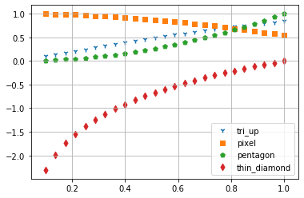

```python
fig, ax = plt.subplots()

x = np.linspace(0.1,1,25)

funcs = [np.sin(x), np.cos(x), x**2, np.log(x)]
marks = ['1',',','p','d']
legs = ['tri_up','pixel','pentagon','thin_diamond']

for f, m, leg in zip(funcs, marks, legs):
    ax.scatter(x, f, marker = m, label = leg)

ax.grid()
ax.legend();
```

This example illustrates 3 things:

1. We can add a legend to the `axes` with the `legend()` method. The values in the legend are set by the `label` parameter in the plotting method.
2. Creating a grid is done with the `grid()` method.
3. We can overlay plots by simply plotting again after a single plot has been created.

Titles and axis labels can be added using the `set_title()`, `set_xlabel()`, and `set_ylabel()` methods.

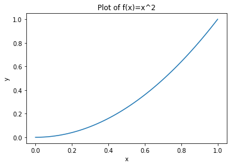

```python
fig, ax = plt.subplots()

x = np.linspace(0,1,100)
y = x**2

ax.plot(x,y);
ax.set_title('Plot of f(x)=x^2');
ax.set_xlabel('x');
ax.set_ylabel('y');
```

While this simple text is often enough for most cases, we can use LaTeX formatting for improved rendering of mathematical expressions.

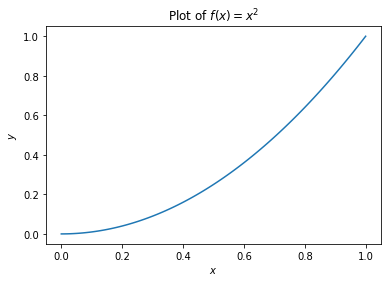

```python
fig, ax = plt.subplots()

x = np.linspace(0,1,100)
y = x**2

ax.plot(x,y);
ax.set_title(r'Plot of $f(x)=x^2$');
ax.set_xlabel(r'$x$');
ax.set_ylabel(r'$y$');
```

## *Example:* 2D scatterplot

When we talk about regression analysis, we'll refer to *linear* relationships between numerical variables. This assumption of linearity is often checked visually through a scatterplot.

In this example, we'll create a scatterplot of two numeric variables for two different datasets. We'll label our axes appropriately, set titles, and visually check if there might be linear relationships between variables.

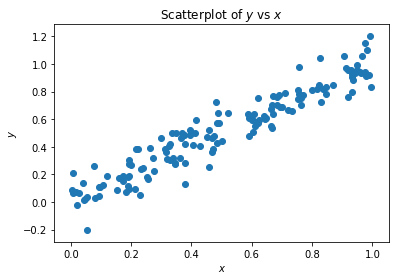

```python
# Dataset 1

data1_x = np.random.rand(150)
data1_y = data1_x + 0.1*np.random.randn(150)

fig, ax = plt.subplots()

ax.scatter(data1_x, data1_y)
ax.set_title(r'Scatterplot of $y$ vs $x$')
ax.set_xlabel(r'$x$')
ax.set_ylabel(r'$y$');
```

From the above scatterplot, it appears that there is a strong linear relationship between $x$ and $y$.

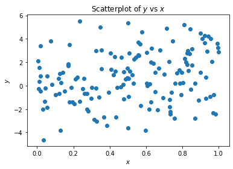

```python
# Dataset 2

data2_x = np.random.rand(150)
data2_y = data2_x + 2*np.random.randn(150)

fig, ax = plt.subplots()

ax.scatter(data2_x, data2_y)
ax.set_title(r'Scatterplot of $y$ vs $x$')
ax.set_xlabel(r'$x$')
ax.set_ylabel(r'$y$');
```

From the above scatterplot, it appears that there is not a strong linear relationship between $x$ and $y$.

## Styling plots

There are even more options for setting the style of titles, axes, and legends within plots. To see the full range of pre-formatted options, we print the list of styles contained in `plt.style.available`. To choose a style, use `plt.style.use('<style name>')`.

```python
print(plt.style.available)
```

[output not shown]

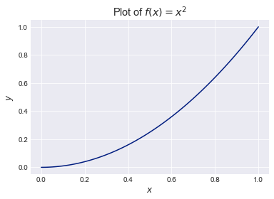

```python
plt.style.use('seaborn-dark-palette')

fig, ax = plt.subplots()

x = np.linspace(0,1,100)
y = x**2

ax.plot(x,y);
ax.set_title(r'Plot of $f(x)=x^2$');
ax.set_xlabel(r'$x$');
ax.set_ylabel(r'$y$');
```

There are many other options for specifying plot styles. To set the locations of tick marks on either the horizontal or vertical axis, use the respective methods:

```
ax.set_xticks(<list of x-tick locations>)
```

or

```
ax.set_yticks(<list of y-tick locations>)
```

We may also turn the grid on or off using

```
ax.grid(<boolean>)
```

## Types of plots in Matplotlib

We can display many more plots than just line plots and scatterplots. For example, we can represent 3D data in a 2D plot with the `contour`, `contourf`, or `pcolormesh` plots.

**Note:** we can use the `set()` method to set a wide range of plot attributes by keyworded argument (or dictionary).

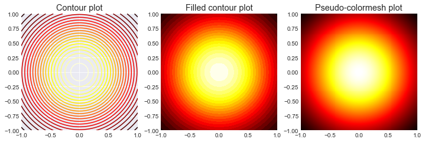

```python
xx, yy = np.meshgrid(np.linspace(-1,1,200),np.linspace(-1,1,200))

z = np.exp(-(xx**2 + yy**2))/np.sqrt(2*np.pi)

fig, ax = plt.subplots(1, 3, figsize = (12,4))

ax[0].contour(xx, yy, z, levels = 25, cmap = 'hot')
ax[0].set(title = 'Contour plot', aspect = 'equal')

ax[1].contourf(xx, yy, z, levels = 25, cmap = 'hot')
ax[1].set(title = 'Filled contour plot', aspect = 'equal')

ax[2].pcolormesh(xx,yy,z, cmap = 'hot')
ax[2].set(title = 'Pseudo-colormesh plot', aspect = 'equal');
```

A less-used but visually striking plot is the `hexplot`.

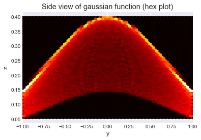

```python
fig, ax = plt.subplots()

ax.hexbin(yy, z, gridsize=50, cmap='hot');
ax.set(title = 'Side view of gaussian function (hex plot)',
       xlim = [-1,1],
       xlabel = 'y',
       ylabel = 'z');
```

For continuous numerical data, we can display the histogram using `hist`.

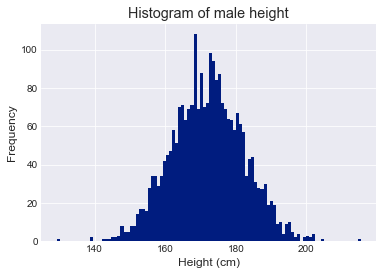

```python
heights = np.random.normal(172, 10, 2500)
fig, ax = plt.subplots()

ax.hist(heights, bins = 100);
ax.set(title = 'Histogram of male height',
       xlabel = 'Height (cm)',
       ylabel = 'Frequency');
```

## Bar charts

Plotting categorical data in bar charts is done with the `bar` and `barh` functions.

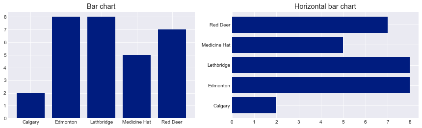

```python
city = ['Calgary','Edmonton','Lethbridge','Medicine Hat','Red Deer']
trai = np.random.randint(1,10,5)

fig, ax = plt.subplots(1,2, figsize = (15,4))

ax[0].bar(city, trai)
ax[0].set_title('Bar chart')

ax[1].barh(city, trai)
ax[1].set_title('Horizontal bar chart');
```

## Pie charts

Pie charts are plotted with the `pie()` method of the `ax` object.

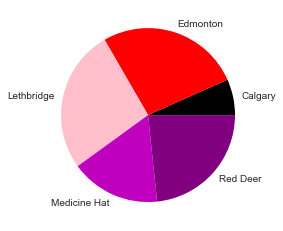

```python
fig, ax = plt.subplots()

ax.pie(trai, labels = city, colors = ['k','r','pink','m','purple']);
```

For smaller pieces of the pie, we can remove the piece from the pie with the `explode` argument. For this argument, we pass in a list with a float in the same index position as the piece we want to highlight. We'll also add a shadow and percentage labels.

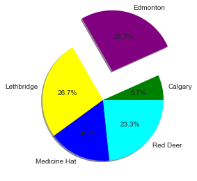

```python
fig, ax = plt.subplots()

ax.pie(trai,
       labels = city,
       explode = [0, 0.5, 0, 0, 0],
       shadow = True,
       autopct = '%1.1f%%',
       colors = ['green','purple','yellow','blue','cyan']);
```

## Plotting from `DataFrame`s

To display any of the above plots for a pandas `DataFrame`, we can pass in the corresponding `DataFrame` row(s) and/or column(s), or we can call the corresponding `DataFrame` method.

For this example, we'll grab the 'World Population by Continent' dataset from Wikipedia.

```python
url = 'https://en.wikipedia.org/wiki/World_population'

data3 = pd.read_html(url, match = 'Population by continent')
```

```python
pop = data3[0]
pop
```

|  | Continent | Density(inhabitants/km2) | Population(millions) | Most populous country | Most populous city (metropolitan area) |
| --- | --- | --- | --- | --- | --- |
| 0 | Asia | 96.4 | 4436 | 1,382,300,000[note 1] – China | 35,676,000/13,634,685 – Greater Tokyo Area/Tok... |
| 1 | Africa | 36.7 | 1216 | 0186,987,000 – Nigeria | 21,000,000 – Lagos |
| 2 | Europe | 72.9 | 738 | 0145,939,000 – Russia;approx. 112 million in E... | 16,855,000/12,506,468 – Moscow metropolitan ar... |
| 3 | North America[note 2] | 22.9 | 579 | 0324,991,600 – United States | 23,723,696/8,537,673 – New York Metropolitan A... |
| 4 | South America | 22.8 | 422 | 0209,567,000 – Brazil | 27,640,577/11,316,149 – Metro Area/São Paulo City |
| 5 | Oceania | 4.5 | 39.9 | 0024,458,800 – Australia | 5,005,400 – Sydney |
| 6 | Antarctica | 0.0003(varies) | 0.004 in summer(non-permanent, varies)[16] | N/A[note 3] | 1,200 (non-permanent, varies) – McMurdo Station |

```python
# A little light cleaning

# Only keep the Continent, Density, and Population columns, and drop Antarctica
pop.drop(index = 6, axis = 0, inplace = True)
pop.drop(columns = ['Most populous country','Most populous city (metropolitan area)'], axis = 1, inplace = True)

# Remove the '[note 2]' from the Continent column
pop['Continent'] = pop['Continent'].apply(lambda x: x.replace('[note 2]',''))

# Rename the columns; convert numeric columns to float
pop.columns = ['Continent', 'Density', 'Population']
pop = pop.apply({'Continent': str, 'Density': float, 'Population': float})

# Set the index to Continent and drop the Continent column
pop.index = pop['Continent']
pop.drop(columns = 'Continent', axis = 1, inplace = True)

# View the cleaned data
pop
```

| Continent | Density | Population |
| --- | --- | --- |
| Asia | 96.4 | 4436.0 |
| Africa | 36.7 | 1216.0 |
| Europe | 72.9 | 738.0 |
| North America | 22.9 | 579.0 |
| South America | 22.8 | 422.0 |
| Oceania | 4.5 | 39.9 |

```python
pop['Population'].plot(kind = 'barh',
                       title = 'World population (millions) by continent');
```

[output not shown]

Many different plots can be generated from pandas objects. The `plot()` method is essentially a *wrapper* for Matplotlib, meaning it serves as a go-between for using Matplotlib. Therefore, knowing Matplotlib should make plotting pandas objects easier to customize.

```python
fig, ax = plt.figure(), pop['Population'].plot(kind = 'barh',
                       title = 'World population (millions) by continent');
```

[output not shown]

The main difference between this plotting method and plotting directly from the pandas object is customizability. We are now dealing directly with an `ax` object, so we can easily change its attributes after the fact.

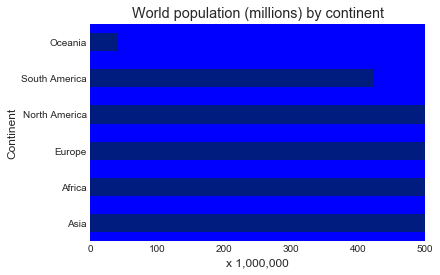

```python
fig, ax = plt.figure(), pop['Population'].plot(kind = 'barh',
                       title = 'World population (millions) by continent');

ax.grid(False)
ax.set(xlim = [0, 500], xlabel = r'x 1,000,000', facecolor = 'b');
```

## Saving plots

A variety of file formats are available for storing Matplotlib plots. Some common file extensions for pixel-based images are `.jpg`, `.png`, `.tif/.tiff`, and `.gif`. Scalable Vector Graphics (`svg`) files are also image files optimized for use on the web and are an excellent choice for saving our plots. These files are essentially `XML` files that allow the image to be smoothly scaled to any size.

Saving plots is done with the `plt.savefig()` function. The saved file format is specified with the `format` argument. Valid values for the `format` argument are `svg`, `jpg`, `png`, `pdf`, and `ps`.

```python
fig, ax = plt.figure(), pop['Population'].plot(kind = 'barh',
                       title = 'World population (millions) by continent');

fig.savefig('worldpop.svg')
fig.savefig('worldpop.png')
```

## *Example:* ANOVA with visualizations

Analysis of Variance (ANOVA) is a statistical technique for comparing mean differences of two or more treatments or populations. As with any hypothesis-testing procedure, we must know the null and alternative hypotheses before we begin the computations. We'll adopt the notation from (Gravetter & Wallnau, 2013).

In ANOVA, the null hypothesis is that there is no significant mean difference between populations. Put mathematically, if we are comparing $k$ populations or treatment groups: $$ H_0: \mu_1 = \mu_2 = \cdots = \mu_k. $$

The alternative hypothesis is that there is a statistically significant difference between the population means. In other words: $$ H_A: \mu_1 \neq \mu_2 \neq \cdots \neq \mu_k. $$

**Note:** only one of the population means must be different in order to reject the null hypothesis. The notation for our alternative hypothesis is just for convenience.

In order to decide whether we fail to reject the null hypothesis or not, we compute the $F$-statistic, which is computed as $$ F = \frac{\text{variance between treatments}}{\text{variance within treatments}}. $$

There are several computations involved in performing ANOVA. We need not write code to compute each of these, since we can use packages.

Suppose we have completed an experiment in which we administered two different brands (Brand A and Brand B) of fertilizer to tomato plants. We want to test if there is a difference between the two brands in plant height after 2 months. If there is a difference, we can recommend one brand as being better than the other.

We will assume that we have 20 plants assigned to each brand of fertilizer, and we have an additional 20 plants given no fertilizer. All other variables, such as pre-fertilizer soil content, soil acidity, water, and light are kept constant. The data is kept in the `tomato.csv` dataset.

```python
try:
    import statsmodels
except:
    !pip install --user statsmodels
```

```python
tomato = pd.read_csv('tomato.csv', index_col = 0)
tomato
```

|  | Control | Brand A | Brand B |
| --- | --- | --- | --- |
| 0 | 6.010831 | 10.908820 | 9.969491 |
| 1 | 5.023822 | 11.076495 | 8.133059 |
| 2 | 6.997431 | 9.853311 | 9.775496 |
| 3 | 7.987032 | 9.186250 | 9.216780 |
| 4 | 7.000895 | 9.955839 | 8.043651 |
| 5 | 4.976122 | 10.665724 | 9.924802 |
| 6 | 6.003509 | 12.878014 | 8.070867 |
| 7 | 6.007099 | 12.067047 | 8.967957 |
| 8 | 4.992056 | 12.958871 | 11.949968 |
| 9 | 5.010229 | 12.747096 | 11.580474 |
| 10 | 4.990943 | 12.920730 | 10.120276 |
| 11 | 9.008853 | 9.043274 | 10.910386 |
| 12 | 4.997795 | 8.952711 | 10.555611 |
| 13 | 9.008716 | 8.972597 | 8.886768 |
| 14 | 4.996706 | 13.261489 | 11.315559 |
| 15 | 4.997956 | 12.199378 | 8.862240 |
| 16 | 4.984390 | 9.844920 | 9.062090 |
| 17 | 7.994484 | 8.614768 | 11.984609 |
| 18 | 7.994530 | 9.103967 | 10.744793 |
| 19 | 8.999642 | 11.785604 | 11.862246 |

Let's look at a plot of the means of each treatment group. The boxplot provides a visualization of the 5-number summary that can be produced with `tomato.describe()`.

```python
tomato.describe()
```

|  | Control | Brand A | Brand B |
| --- | --- | --- | --- |
| count | 20.000000 | 20.000000 | 20.000000 |
| mean | 6.399152 | 10.849845 | 9.996856 |
| std | 1.570783 | 1.630839 | 1.324415 |
| min | 4.976122 | 8.614768 | 8.043651 |
| 25% | 4.997523 | 9.165679 | 8.947659 |
| 50% | 6.005304 | 10.787272 | 9.947147 |
| 75% | 7.988895 | 12.336307 | 11.011680 |
| max | 9.008853 | 13.261489 | 11.984609 |

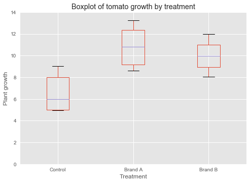

```python
plt.style.use('ggplot')

fig, ax = plt.figure(), tomato.boxplot()

ax.set_title('Boxplot of tomato growth by treatment');
ax.set_xlabel('Treatment')
ax.set_ylabel('Plant growth');
ax.set_ylim([0,14]);
```

By looking at the boxplot, it appears that there is a difference in means between the three treatment groups. We'll now compute the ANOVA using the `f_oneway()` function from the SciPy package (SciPy is an extension of NumPy).

```python
from scipy import stats

F, p = stats.f_oneway(tomato['Control'], tomato['Brand A'], tomato['Brand B'])
print('F-value: {:.4f}\np-value: {:.4f}'.format(F,p))
```

```
F-value: 48.6548
p-value: 0.0000
```

The above output is not very appealing, but it tells us that there is a statistically significant difference between the treatment groups (the $p$-value is far less than 0.05).

Another method of computing ANOVA is with the statsmodels package. A huge benefit of this package is the greatly improved readability of its output. The example below considers the ANOVA as a special case of a general linear model (GLM). What this basically means is that the treatment effect is considered a linear function of the treatment group.

To apply the 'statsmodels' method, we'll rearrange the data from above to make it easier to input to the `ols()` function. This is exactly the same data as above, just organized differently.

```python
tomato2 = tomato.unstack()
tomato2 = pd.DataFrame(tomato2)
tomato2
```

|  |  | 0 |
| --- | --- | --- |
| Control | 0 | 6.010831 |
|  | 1 | 5.023822 |
|  | 2 | 6.997431 |
|  | 3 | 7.987032 |
|  | 4 | 7.000895 |
|  | 5 | 4.976122 |
|  | 6 | 6.003509 |
|  | 7 | 6.007099 |
|  | 8 | 4.992056 |
|  | 9 | 5.010229 |
|  | 10 | 4.990943 |
|  | 11 | 9.008853 |
|  | 12 | 4.997795 |
|  | 13 | 9.008716 |
|  | 14 | 4.996706 |
|  | 15 | 4.997956 |
|  | 16 | 4.984390 |
|  | 17 | 7.994484 |
|  | 18 | 7.994530 |
|  | 19 | 8.999642 |
| Brand A | 0 | 10.908820 |
|  | 1 | 11.076495 |
|  | 2 | 9.853311 |
|  | 3 | 9.186250 |
|  | 4 | 9.955839 |
|  | 5 | 10.665724 |
|  | 6 | 12.878014 |
|  | 7 | 12.067047 |
|  | 8 | 12.958871 |
|  | 9 | 12.747096 |
|  | 10 | 12.920730 |
|  | 11 | 9.043274 |
|  | 12 | 8.952711 |
|  | 13 | 8.972597 |
|  | 14 | 13.261489 |
|  | 15 | 12.199378 |
|  | 16 | 9.844920 |
|  | 17 | 8.614768 |
|  | 18 | 9.103967 |
|  | 19 | 11.785604 |
| Brand B | 0 | 9.969491 |
|  | 1 | 8.133059 |
|  | 2 | 9.775496 |
|  | 3 | 9.216780 |
|  | 4 | 8.043651 |
|  | 5 | 9.924802 |
|  | 6 | 8.070867 |
|  | 7 | 8.967957 |
|  | 8 | 11.949968 |
|  | 9 | 11.580474 |
|  | 10 | 10.120276 |
|  | 11 | 10.910386 |
|  | 12 | 10.555611 |
|  | 13 | 8.886768 |
|  | 14 | 11.315559 |
|  | 15 | 8.862240 |
|  | 16 | 9.062090 |
|  | 17 | 11.984609 |
|  | 18 | 10.744793 |
|  | 19 | 11.862246 |

```python
# Rename the '0' column
tomato2.rename(columns = {0: 'Growth'}, inplace = True)

# Remove the hierarchical index on the left.
tomato2.index = range(60)
tomato2['Group'] = np.zeros(60)

# Create group labels in the 'Group' column
tomato2['Group'].loc[:20] = 'Control'
tomato2['Group'].loc[20:40] = 'A'
tomato2['Group'].loc[40:] = 'B'
tomato2
```

|  | Growth | Group |
| --- | --- | --- |
| 0 | 6.010831 | Control |
| 1 | 5.023822 | Control |
| 2 | 6.997431 | Control |
| 3 | 7.987032 | Control |
| 4 | 7.000895 | Control |
| 5 | 4.976122 | Control |
| 6 | 6.003509 | Control |
| 7 | 6.007099 | Control |
| 8 | 4.992056 | Control |
| 9 | 5.010229 | Control |
| 10 | 4.990943 | Control |
| 11 | 9.008853 | Control |
| 12 | 4.997795 | Control |
| 13 | 9.008716 | Control |
| 14 | 4.996706 | Control |
| 15 | 4.997956 | Control |
| 16 | 4.984390 | Control |
| 17 | 7.994484 | Control |
| 18 | 7.994530 | Control |
| 19 | 8.999642 | Control |
| 20 | 10.908820 | A |
| 21 | 11.076495 | A |
| 22 | 9.853311 | A |
| 23 | 9.186250 | A |
| 24 | 9.955839 | A |
| 25 | 10.665724 | A |
| 26 | 12.878014 | A |
| 27 | 12.067047 | A |
| 28 | 12.958871 | A |
| 29 | 12.747096 | A |
| 30 | 12.920730 | A |
| 31 | 9.043274 | A |
| 32 | 8.952711 | A |
| 33 | 8.972597 | A |
| 34 | 13.261489 | A |
| 35 | 12.199378 | A |
| 36 | 9.844920 | A |
| 37 | 8.614768 | A |
| 38 | 9.103967 | A |
| 39 | 11.785604 | A |
| 40 | 9.969491 | B |
| 41 | 8.133059 | B |
| 42 | 9.775496 | B |
| 43 | 9.216780 | B |
| 44 | 8.043651 | B |
| 45 | 9.924802 | B |
| 46 | 8.070867 | B |
| 47 | 8.967957 | B |
| 48 | 11.949968 | B |
| 49 | 11.580474 | B |
| 50 | 10.120276 | B |
| 51 | 10.910386 | B |
| 52 | 10.555611 | B |
| 53 | 8.886768 | B |
| 54 | 11.315559 | B |
| 55 | 8.862240 | B |
| 56 | 9.062090 | B |
| 57 | 11.984609 | B |
| 58 | 10.744793 | B |
| 59 | 11.862246 | B |

```python
import statsmodels.api as sm
from statsmodels.formula.api import ols
```

```python
# Create the linear model

model = ols('Growth ~ Group', data = tomato2).fit();
```

```python
# Perform the ANOVA

anova = sm.stats.anova_lm(model)
anova
```

|  | df | sum_sq | mean_sq | F | PR(>F) |
| --- | --- | --- | --- | --- | --- |
| Group | 2.0 | 223.198240 | 111.59912 | 48.654832 | 4.712261e-13 |
| Residual | 57.0 | 130.740352 | 2.29369 | NaN | NaN |

The above table shows the degrees of freedom, the sum of squares, $F$ statistic, and the $p$-value for the $F$ statistic. We can also see this information (and much, much more) by looking at the model summary.

```python
print(model.summary())
```

```
                            OLS Regression Results
==============================================================================
Dep. Variable:                 Growth   R-squared:                       0.631
Model:                            OLS   Adj. R-squared:                  0.618
Method:                 Least Squares   F-statistic:                     48.65
Date:                Wed, 11 Mar 2020   Prob (F-statistic):           4.71e-13
Time:                        20:10:25   Log-Likelihood:                -108.50
No. Observations:                  60   AIC:                             223.0
Df Residuals:                      57   BIC:                             229.3
Df Model:                           2
Covariance Type:            nonrobust
====================================================================================
                       coef    std err          t      P>|t|      [0.025      0.975]
------------------------------------------------------------------------------------
Intercept           10.8498      0.339     32.038      0.000      10.172      11.528
Group[T.B]          -0.8530      0.479     -1.781      0.080      -1.812       0.106
Group[T.Control]    -4.4507      0.479     -9.293      0.000      -5.410      -3.492
==============================================================================
Omnibus:                       26.020   Durbin-Watson:                   1.583
Prob(Omnibus):                  0.000   Jarque-Bera (JB):                5.079
Skew:                           0.276   Prob(JB):                       0.0789
Kurtosis:                       1.686   Cond. No.                         3.73
==============================================================================

Warnings:
[1] Standard Errors assume that the covariance matrix of the errors is correctly specified.
```

We may convert the model summary to a comma-separated string using the `as_csv(<file path>)` method. We can then save the model summary as a `csv` as follows.

```python
with open('anova_summary.csv', 'w') as file:
    file.write(model.summary().as_csv())
```

## *Example:* Linear regression with visualizations - Synthetic data

To find the coefficients $\beta_0$ and $\beta_1$, we'll fit a linear regression using the statsmodels package.

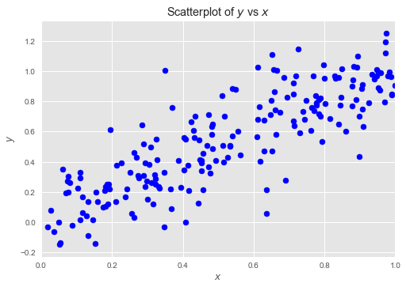

```python
x = np.random.rand(200)
y = x + 0.18*np.random.randn(200)

example_data = pd.DataFrame({'x': x, 'y': y})

fig, ax = plt.subplots()

ax.scatter(x, y, color = 'b')
ax.set(title = r'Scatterplot of $y$ vs $x$',
       xlabel = r'$x$',
       ylabel = r'$y$',
       xlim = [0, 1]);
```

```python
# Fitting the model

model1 = ols('y ~ x', data = example_data).fit()
print(model1.summary())
```

```
                            OLS Regression Results
==============================================================================
Dep. Variable:                      y   R-squared:                       0.699
Model:                            OLS   Adj. R-squared:                  0.697
Method:                 Least Squares   F-statistic:                     459.1
Date:                Wed, 11 Mar 2020   Prob (F-statistic):           1.79e-53
Time:                        20:17:57   Log-Likelihood:                 58.479
No. Observations:                 200   AIC:                            -113.0
Df Residuals:                     198   BIC:                            -106.4
Df Model:                           1
Covariance Type:            nonrobust
==============================================================================
                 coef    std err          t      P>|t|      [0.025      0.975]
------------------------------------------------------------------------------
Intercept      0.0331      0.027      1.231      0.220      -0.020       0.086
x              0.9675      0.045     21.427      0.000       0.878       1.056
==============================================================================
Omnibus:                        4.383   Durbin-Watson:                   1.966
Prob(Omnibus):                  0.112   Jarque-Bera (JB):                5.620
Skew:                           0.065   Prob(JB):                       0.0602
Kurtosis:                       3.811   Cond. No.                         4.55
==============================================================================

Warnings:
[1] Standard Errors assume that the covariance matrix of the errors is correctly specified.
```

The output above shows that the Intercept ($\beta_0$) has approximate value 0.0331 and a $p$-value > 0.05, meaning that this coefficient is not statistically significant.

Similarly, the 'x' coefficient ($\beta_1$) has approximate value 0.9675 and $p$-value ~ 0.

There are two methods for producing the line of best fit:

- We could generate a new sample of $x$-values and predict the corresponding $y$-values based on the model. To get the predictions, we would either use the `model.predict(x_pred)` method, or we could generate predictions ourselves by the formula $$

  ```
    \text{y}_p = 0.0331 + 0.9675x_p,
  ```

  $$ where $x_p$ are the $x$-values newly generated for prediction. To access the values of $\beta_0$ and $\beta_1$, we could call `model1.params` and grab the desired parameter by index.
- Just use the statsmodels `graphics.abline_plot()` method. The arguments are the fitted model and the `axes` object for plotting.

**Note:** The `ols` object is picky about its inputs for its `predict()` method. It only accepts pandas `DataFrame` objects.

```python
model1.params
```

```
Intercept    0.033144
x            0.967457
dtype: float64
```

```python
xp = pd.DataFrame(np.linspace(0,1,200))
yp = model1.predict(xp).sort_values()
```

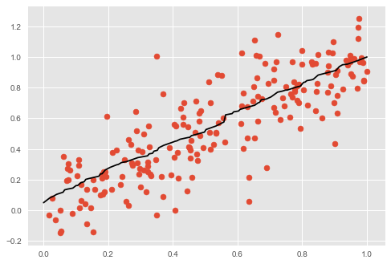

```python
fig, ax = plt.subplots()

ax.scatter(x, y);
ax.plot(xp, yp, color = 'k');
```

We'll now plot the line of best fit using the `graphics.abline_plot()` method.

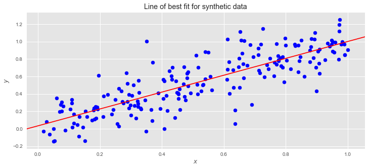

```python
# Plotting the line of best fit over the scatterplot

fig, ax = plt.subplots(figsize = (12,5))

# Scatterplot of the data
ax.scatter(x, y, color = 'b')

# Plotting the line of best fit
sm.graphics.abline_plot(model_results = model1, ax = ax, color = 'r');
ax.set(title = 'Line of best fit for synthetic data',
       xlabel = r'$x$',
       ylabel = r'$y$');
```

## *Example:* Linear regression with visualizations - Real data

Last day we explored the WHO data on the prevalence of depression across the world. Today we'll see if there might be a linear relationship between the prevalence of depression ($y$) and the number of psychiatrists ($x_1$) and psychologists ($x_2$). In particular, we want to know if we can predict $y$ given values of $x_1$ and $x_2$. For now, we'll assume the simple linear model $$ y = \beta_0 + \beta_1x_1 + \beta_2x_2 + \varepsilon. $$

**Note:** Remember that the number of doctors is given per 100,000 people. **Note:** We'll go into far more detail about regression next week. For now, we are more interested in the visuals.

Let's load in the data and make some plots. Because we want to check linearity, we'll plot $y$ vs $x_1$ and $y$ vs $x_2$.

```python
p1 = pd.read_excel('psychiatrists.xlsx', header = 2)
p1 = p1[['Location','FactValueForMeasure']]
p1.rename(columns = {'Location': 'Country',
                     'FactValueForMeasure': 'psychiatrists'},
          inplace = True)
p1
```

|  | Country | psychiatrists |
| --- | --- | --- |
| 0 | Afghanistan | 0.230 |
| 1 | Albania | 1.470 |
| 2 | Angola | 0.057 |
| 3 | Antigua and Barbuda | 1.000 |
| 4 | Argentina | 21.710 |
| ... | ... | ... |
| 141 | Uzbekistan | 2.610 |
| 142 | Vanuatu | 0.380 |
| 143 | Yemen | 0.200 |
| 144 | Zambia | 0.056 |
| 145 | Zimbabwe | 0.095 |

146 rows × 2 columns

```python
p2 = pd.read_excel('psychologists.xlsx', header = 2)
p2 = p2[['Location','FactValueForMeasure']]
p2.rename(columns = {'Location':'Country',
                     'FactValueForMeasure':'psychologists'},
          inplace = True)
p2
```

|  | Country | psychologists |
| --- | --- | --- |
| 0 | Afghanistan | 0.300 |
| 1 | Albania | 1.230 |
| 2 | Angola | 0.180 |
| 3 | Argentina | 222.600 |
| 4 | Armenia | 0.790 |
| ... | ... | ... |
| 115 | Uzbekistan | 0.090 |
| 116 | Vanuatu | 0.760 |
| 117 | Yemen | 0.410 |
| 118 | Zambia | 0.031 |
| 119 | Zimbabwe | 0.057 |

120 rows × 2 columns

```python
dep = pd.read_excel('WHO_depression.xlsx', header = 2)
dep = dep[['Location','FactValueForMeasure']]
dep.rename(columns = {'Location':'Country',
                      'FactValueForMeasure':'prevalence'},
           inplace = True)
dep
```

|  | Country | prevalence |
| --- | --- | --- |
| 0 | Afghanistan | 3.31 |
| 1 | Albania | 4.78 |
| 2 | Algeria | 4.53 |
| 3 | Angola | 3.65 |
| 4 | Antigua and Barbuda | 5.06 |
| ... | ... | ... |
| 178 | Venezuela (Bolivarian Republic of) | 4.21 |
| 179 | Viet Nam | 4.01 |
| 180 | Yemen | 3.57 |
| 181 | Zambia | 4.01 |
| 182 | Zimbabwe | 4.04 |

183 rows × 2 columns

```python
# Combining the datasets with a merge where the country matches.
data = pd.merge(p1, p2, on = 'Country')
data
```

|  | Country | psychiatrists | psychologists |
| --- | --- | --- | --- |
| 0 | Afghanistan | 0.230 | 0.300 |
| 1 | Albania | 1.470 | 1.230 |
| 2 | Angola | 0.057 | 0.180 |
| 3 | Argentina | 21.710 | 222.600 |
| 4 | Armenia | 3.840 | 0.790 |
| ... | ... | ... | ... |
| 111 | Uzbekistan | 2.610 | 0.090 |
| 112 | Vanuatu | 0.380 | 0.760 |
| 113 | Yemen | 0.200 | 0.410 |
| 114 | Zambia | 0.056 | 0.031 |
| 115 | Zimbabwe | 0.095 | 0.057 |

116 rows × 3 columns

```python
data = pd.merge(data, dep, on = 'Country')
data
```

|  | Country | psychiatrists | psychologists | prevalence |
| --- | --- | --- | --- | --- |
| 0 | Afghanistan | 0.230 | 0.300 | 3.31 |
| 1 | Albania | 1.470 | 1.230 | 4.78 |
| 2 | Angola | 0.057 | 0.180 | 3.65 |
| 3 | Argentina | 21.710 | 222.600 | 4.73 |
| 4 | Armenia | 3.840 | 0.790 | 4.99 |
| ... | ... | ... | ... | ... |
| 108 | Uzbekistan | 2.610 | 0.090 | 4.23 |
| 109 | Vanuatu | 0.380 | 0.760 | 3.09 |
| 110 | Yemen | 0.200 | 0.410 | 3.57 |
| 111 | Zambia | 0.056 | 0.031 | 4.01 |
| 112 | Zimbabwe | 0.095 | 0.057 | 4.04 |

113 rows × 4 columns

```python
data.rename(columns = {'prevalence':'y',
                       'psychiatrists':'x1',
                       'psychologists':'x2'},
            inplace = True)
data
```

|  | Country | x1 | x2 | y |
| --- | --- | --- | --- | --- |
| 0 | Afghanistan | 0.230 | 0.300 | 3.31 |
| 1 | Albania | 1.470 | 1.230 | 4.78 |
| 2 | Angola | 0.057 | 0.180 | 3.65 |
| 3 | Argentina | 21.710 | 222.600 | 4.73 |
| 4 | Armenia | 3.840 | 0.790 | 4.99 |
| ... | ... | ... | ... | ... |
| 108 | Uzbekistan | 2.610 | 0.090 | 4.23 |
| 109 | Vanuatu | 0.380 | 0.760 | 3.09 |
| 110 | Yemen | 0.200 | 0.410 | 3.57 |
| 111 | Zambia | 0.056 | 0.031 | 4.01 |
| 112 | Zimbabwe | 0.095 | 0.057 | 4.04 |

113 rows × 4 columns

```python
data[data['Country'] == 'Germany']
```

|  | Country | x1 | x2 | y |
| --- | --- | --- | --- | --- |
| 39 | Germany | 13.2 | 49.55 | 5.19 |

We don't really need the `Country` column anymore, so we'll drop it.

```python
data.drop('Country', axis = 1, inplace = True)
data
```

|  | x1 | x2 | y |
| --- | --- | --- | --- |
| 0 | 0.230 | 0.300 | 3.31 |
| 1 | 1.470 | 1.230 | 4.78 |
| 2 | 0.057 | 0.180 | 3.65 |
| 3 | 21.710 | 222.600 | 4.73 |
| 4 | 3.840 | 0.790 | 4.99 |
| ... | ... | ... | ... |
| 108 | 2.610 | 0.090 | 4.23 |
| 109 | 0.380 | 0.760 | 3.09 |
| 110 | 0.200 | 0.410 | 3.57 |
| 111 | 0.056 | 0.031 | 4.01 |
| 112 | 0.095 | 0.057 | 4.04 |

113 rows × 3 columns

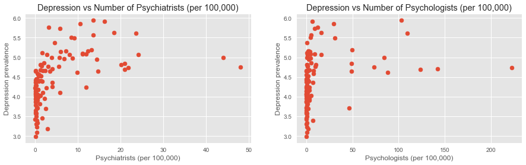

```python
# Plotting y vs x1 and y vs x2
fig, ax = plt.subplots(1, 2, figsize = (15,4))

ax[0].scatter(data['x1'], data['y'])
ax[0].set(title = 'Depression vs Number of Psychiatrists (per 100,000)',
          xlabel = 'Psychiatrists (per 100,000)',
          ylabel = 'Depression prevalence');
ax[0].grid(True);


ax[1].scatter(data['x2'], data['y']);
ax[1].set(title = 'Depression vs Number of Psychologists (per 100,000)',
          xlabel = 'Psychologists (per 100,000)',
          ylabel = 'Depression prevalence');
ax[1].grid(True);
```

Though the plots show that there is likely not a linear relationship between $y$ and either of the variables $x_1$ or $x_2$, we'll fit the linear regression anyways.

```python
model2 = ols('y ~ x1 + x2', data = data).fit()
```

```python
print(model2.summary())
```

```
                            OLS Regression Results
==============================================================================
Dep. Variable:                      y   R-squared:                       0.263
Model:                            OLS   Adj. R-squared:                  0.249
Method:                 Least Squares   F-statistic:                     19.62
Date:                Wed, 11 Mar 2020   Prob (F-statistic):           5.18e-08
Time:                        20:32:46   Log-Likelihood:                -96.295
No. Observations:                 113   AIC:                             198.6
Df Residuals:                     110   BIC:                             206.8
Df Model:                           2
Covariance Type:            nonrobust
==============================================================================
                 coef    std err          t      P>|t|      [0.025      0.975]
------------------------------------------------------------------------------
Intercept      4.2302      0.063     66.724      0.000       4.105       4.356
x1             0.0425      0.008      5.203      0.000       0.026       0.059
x2            -0.0004      0.002     -0.207      0.837      -0.004       0.004
==============================================================================
Omnibus:                        0.075   Durbin-Watson:                   1.915
Prob(Omnibus):                  0.963   Jarque-Bera (JB):                0.112
Skew:                          -0.058   Prob(JB):                        0.945
Kurtosis:                       2.899   Cond. No.                         42.1
==============================================================================

Warnings:
[1] Standard Errors assume that the covariance matrix of the errors is correctly specified.
```

Many more plots are available using the statsmodels package, but we'll forego their introduction here. Instead, I'll provide a [link](https://www.statsmodels.org/dev/examples/notebooks/generated/regression_plots.html) to their documentation and some examples of their use.

The graphic below is a plot of the dependent variable (`y`) vs each independent variable of our model (`x1`, `x2`, and the intercept) after taking into account the other variables.

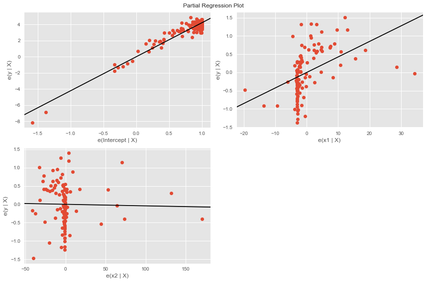

```python
fig = plt.figure(figsize=(12,8))
fig = sm.graphics.plot_partregress_grid(model2, fig=fig)
```

For the `x1` variable, the next plot shows the fitted values with confidence intervals, the model residuals against `x1`, a partial regression plot (duplicated from above), and a Component-Component plus Residual (CCPR) plot.

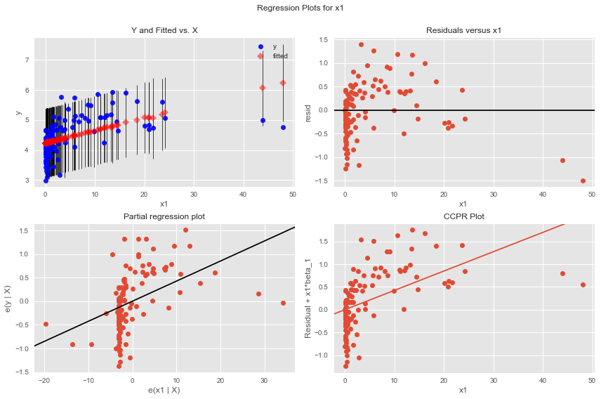

```python
fig = plt.figure(figsize=(12,8))
fig = sm.graphics.plot_regress_exog(model2, "x1", fig=fig)
```

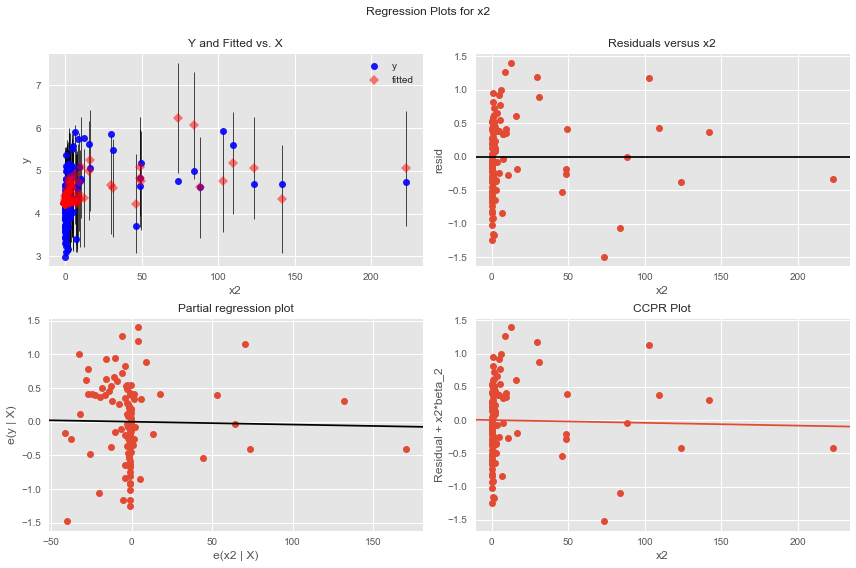

```python
fig = plt.figure(figsize=(12,8))
fig = sm.graphics.plot_regress_exog(model2, "x2", fig=fig)
```

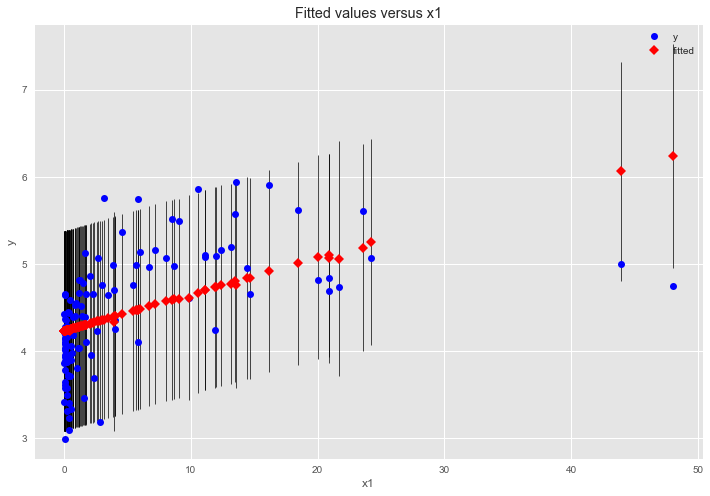

```python
fig, ax = plt.subplots(figsize=(12, 8))
fig = sm.graphics.plot_fit(model2, "x1", ax=ax)
```

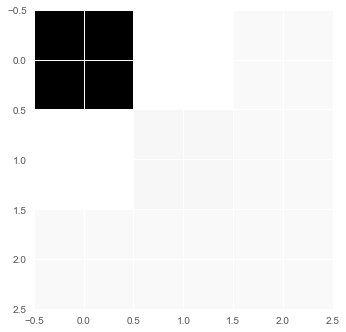

```python
plt.imshow(model2.cov_params());
```

```python
help(sm.graphics.abline_plot)
```

[output not shown]

# Summary

- Matplotlib is the fundamental plotting library for Python. Almost all other plotting packages are based on Matplotlib.
- The fundamental plotting objects are the `figure` and the `axes`.
- Many types of common 2D plots are available through Matplotlib.
- A collection of plotting examples is available at the [Matplotlib Gallery](https://matplotlib.org/3.1.1/gallery/index.html#examples-index).
- ANOVA can be computed using the statsmodels package.
- Linear regression can be computed using the statsmodels package, which has a module for visualizations.

# *Exercises*

1. Create an array of 150 points between $0$ and $2\pi$ using `x = np.linspace(0,2*np.pi,150)`.

   a. Plot `sin(x)`, `cos(x)`, and `tan(x)` on the same axes.

   b. Plot `sin(x)`, `cos(x)`, and `tan(x)` on 3 side-by-side axes in the same figure.
1. This exercise uses the `govttimeseries.xlsx` dataset from Day 4. The cleaned data is found in the `govt.csv` file. Create a single figure with 2 rows of 5 axes. On each axis, display the `Amount` data for 5 states (ignore the District of Columbia) using a line plot. The `Amount` variable will be on the vertical axis and the `Year` will be on the horizontal axis.

```python
govt = pd.read_csv('govt.csv')
govt
```

1. For the WHO depression data, plot the prevalence of depression vs `x1**2`, `x2**2`, and `x1*x2`. Comment on any possible linear relationships.

# References

Gravetter, F. J., & Wallnau, L. B. (2013). Statistics for the Behavioral Sciences (9 ed.). Belmont, CA: Wadsworth.